# Experiment 5: some with time pressure

### Before Exclusions

**Number of participants tested:**

```
## [1] 1200
```

**Participants in each condition:**

```
##
## all_QUD any_QUD  no_QUD
##     400     400     400
```

### Exclusions

**Non-unique participants (remove all attempts):**

```
## [1] 1124
```

**Participants whose native language is not english:**

```
##    workerid   language
## 1        51      Dutch
## 2        53    Spanish
## 3        72
## 4        81  malayalam
## 5       118
## 6       122
## 7       123    Spanish
## 8       127
## 9       178 Vietnamese
## 10      214     Polish
## 11      231
## 12      273   Gujarati
## 13      348    chinese
## 14      440
```

[output cut: 21 more lines]

**Participants who got the second comprehension question wrong more than twice:**

```
## # A tibble: 15 x 2
## # Groups:   workerid [15]
##    workerid     n
##       <int> <int>
##  1       16     3
##  2       24     3
##  3      261     3
##  4      298     8
##  5      317     3
##  6      446     4
##  7      516     3
##  8      603     5
##  9      608     3
## 10      652     3
## 11      688     3
## 12      716     3
## 13      752     3
## 14      757     3
## 15      761     4
```

**Participants with accuracy of lower than 85% on non-critical trials with “some”,“none”,“all” and numbers below 6:**

```
##     workerid gaveRightAnswer  n answerNm  accuracy
## 1          1               1 22       43 51.162791
## 2          6               1 19       46 41.304348
## 3         10               1 22       47 46.808511
## 4         13               1 28       48 58.333333
## 5         31               1 24       40 60.000000
## 6         32               1 16       39 41.025641
## 7         35               1 19       47 40.425532
## 8         44               1 20       44 45.454545
## 9         49               1 39       48 81.250000
## 10        55               1 26       45 57.777778
## 11        60               1 17       34 50.000000
## 12        61               1 19       39 48.717949
## 13        62               1 38       46 82.608696
## 14        63               1 27       38 71.052632
```

[output cut: 257 more lines]

#### Additional Exclusions

**Participants who gave more than 5 very slow (logRT>20) responses:**

```
## # A tibble: 0 x 3
## # Groups:   workerid [0]
## # … with 3 variables: workerid <int>, slowResponse <lgl>, n <int>
```

**Responses that are faster than the onset of the quantifier (rawRT<600):**

```
## [1] 566
```

**Responses that are very slow (logRT>20):**

```
## [1] 40
```

## After Exclusions

**Number of participants:**

```
## [1] 877
```

**Participants left in each condition:**

```
##
## all_QUD any_QUD  no_QUD
##     292     281     304
```

## General

**Expected number of yes and no answers:**

```
##
##    No   Yes
## 24289 28725
```

**Accuracy**

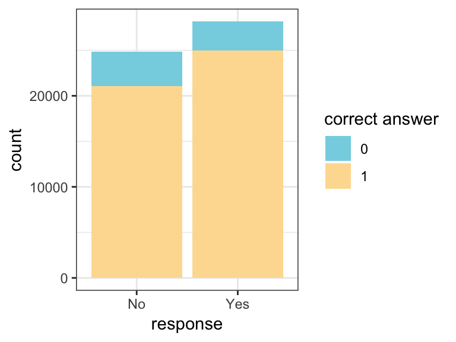

**Accuracy and trial order**

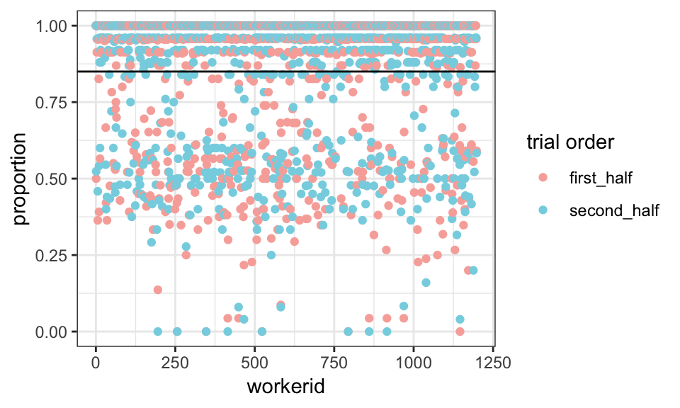

**Distribution of RT and logRT**

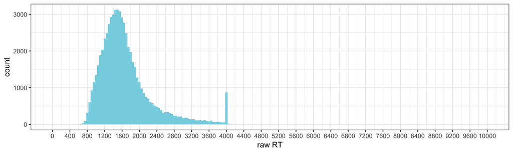

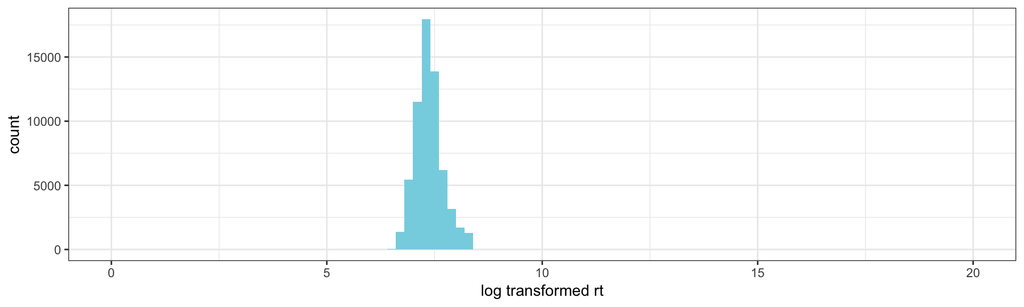

15 fastest responses (raw RT)

```
##  [1] 609 626 633 654 664 664 667 672 676 682 682 683 683 688 694
```

15 slowest responses (raw RT)

```
##  [1] 4028 4028 4029 4030 4031 4038 4041 4042 4044 4062 4071 4096 4117 4210
## [15] 4324
```

### Non-critical Trials

**Response type:**

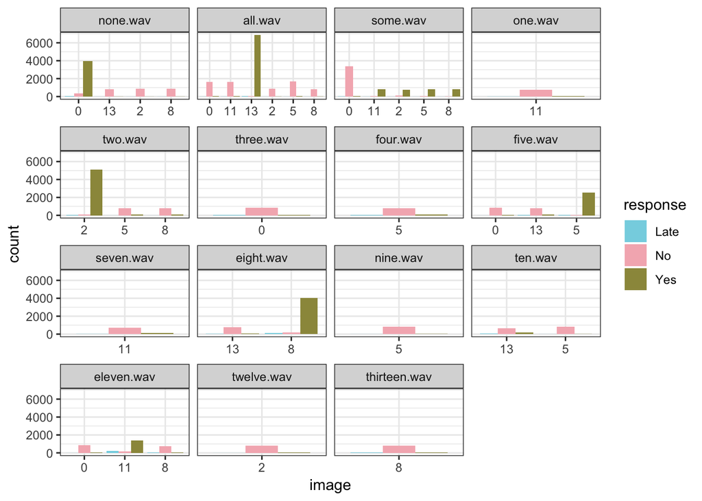

**Response time:**

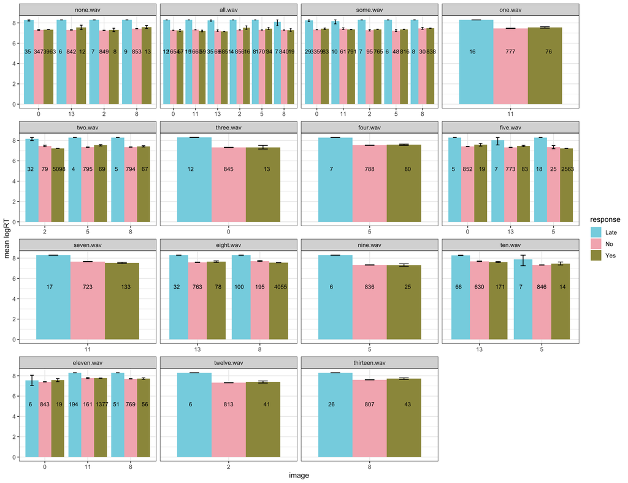

### Critical Trials

**Total number of critical trials (8 per participant):**

```
## [1] 6940
```

**Total number of critical trials with late responses removed:**

```
## [1] 6869
```

#### Response Type

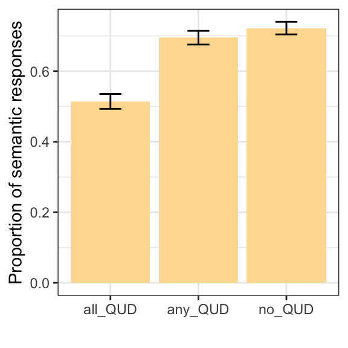

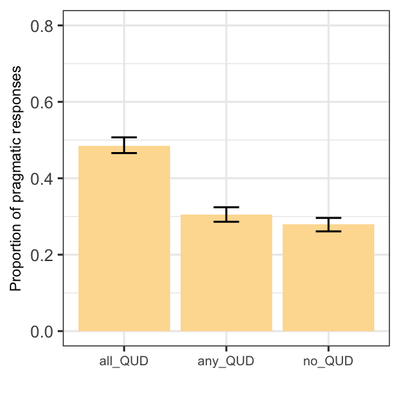

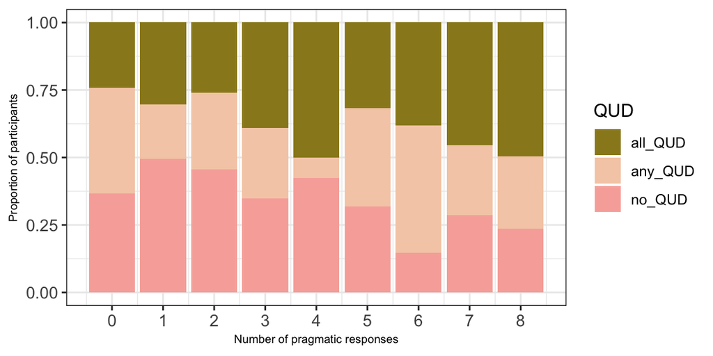

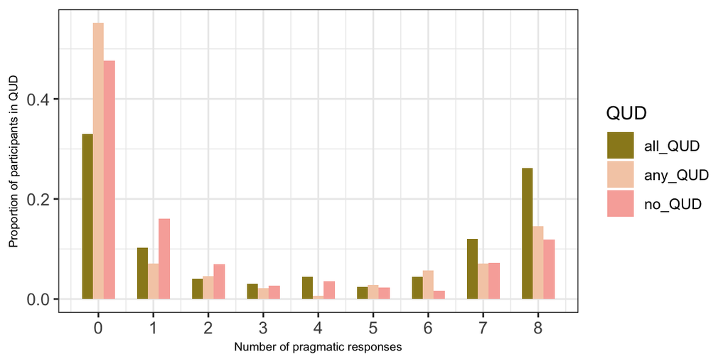

**Response type and trial order**

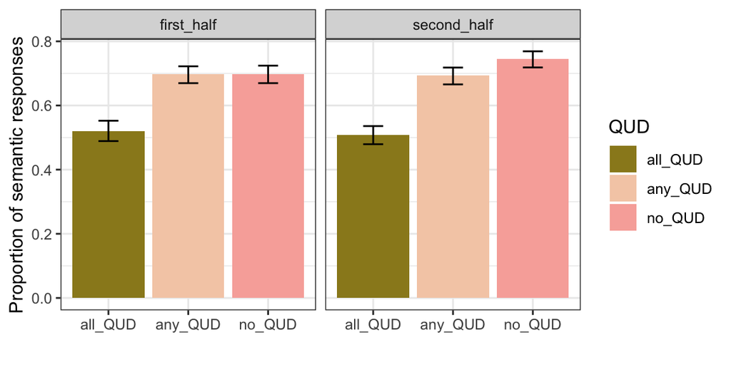

**Age distribution of participants**

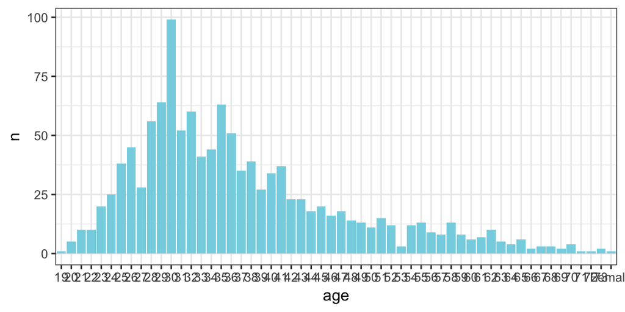

**Response type and age**

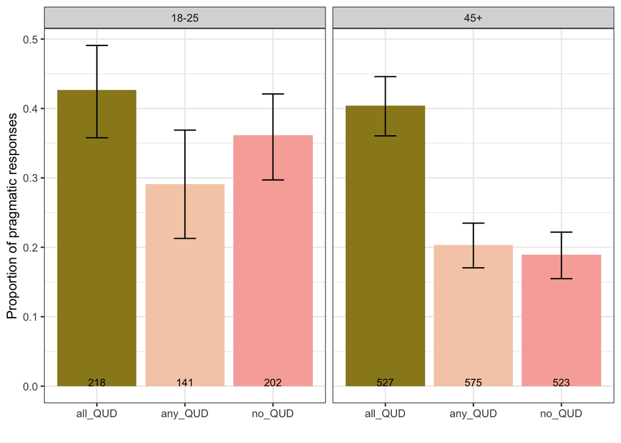

#### Response Time

**Distribution of response times in critical trials**

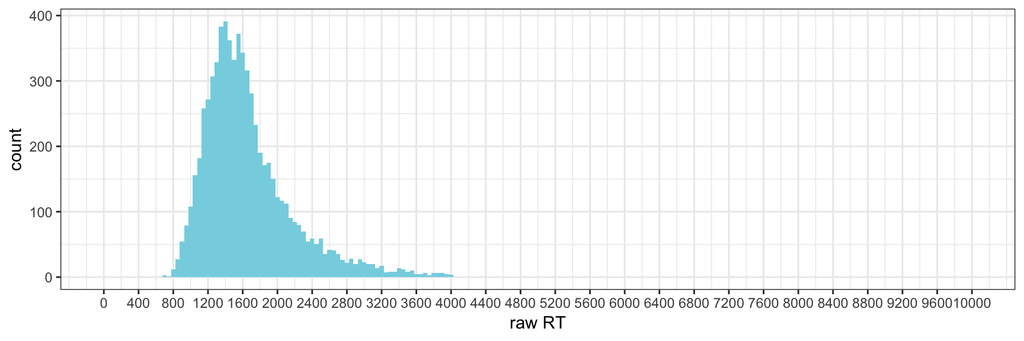

**Response time and QUD**

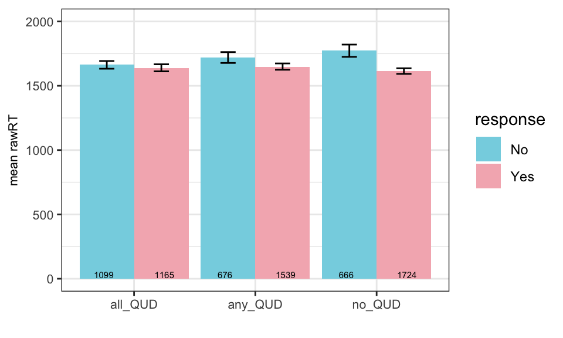

**Response time, trial order and QUD**

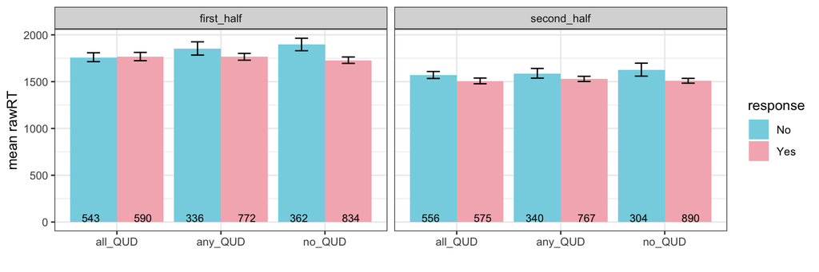

**Response time, responder type and QUD**

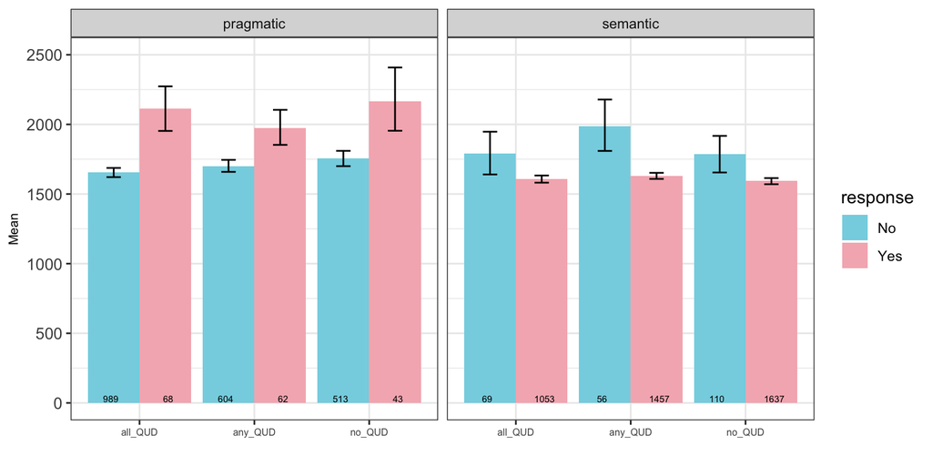

**Response time, age and QUD**

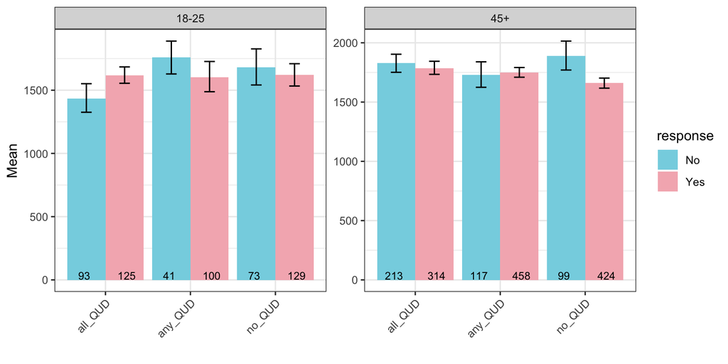

**Response time, age, responder type and QUD**

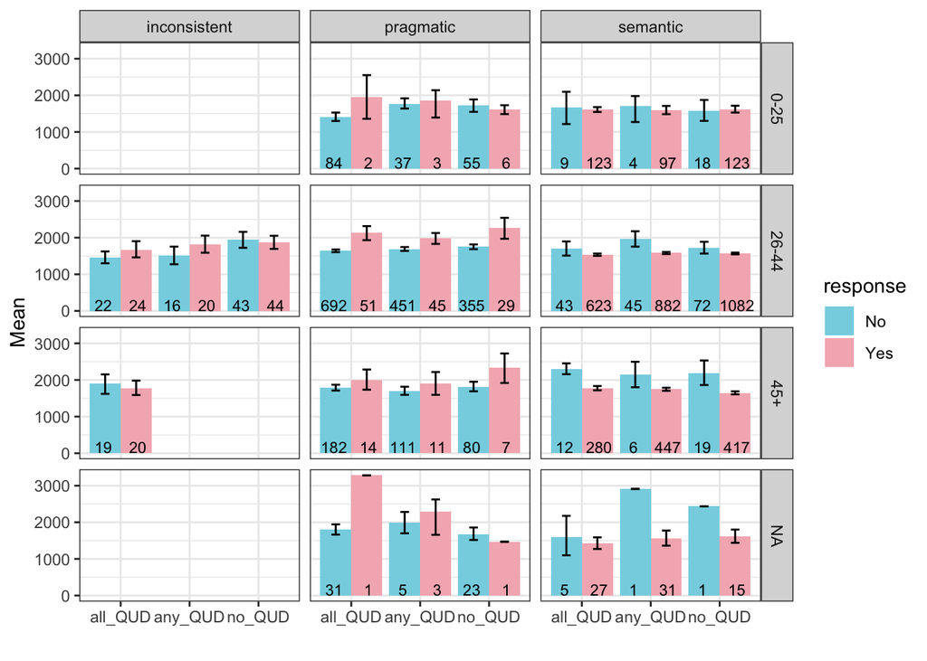

**Models**